# TimeseriesAnalysis

Lawrence Ramsay

2023-11-14

```r
prc[, .N, by = year(dte)]
```

```
##     year   N
##  1: 2012 184
##  2: 2013 252
##  3: 2014 252
##  4: 2015 252
##  5: 2016 250
##  6: 2017 251
##  7: 2018 251
##  8: 2019 252
##  9: 2020 253
## 10: 2021 252
## 11: 2022 251
## 12: 2023 123
```

## Overview

This report takes us through forecasting Turkish Rebar and how the effects of seasonality can help the forecasting. This report has quite a lot of experimentation so it meant to be read more like a story.

It follows the following stages:

1. Visualising the data
2. Viewing the statistical properties
- This is to check if the data needs to be transformed to create a better forecast

## Codes

The codes we are using and what they are referring to. I refer to the Turkish price as the crude because that is what we are trying to forecast at the end of the day. The ironore is the price we are comparing to. This can be anything we think could be similar.

```r
reactable::reactable(test_prc_symb)
```

| cde | type | desc |
| --- | --- | --- |
| close_crd | crude | Crude Oil |
| close_irn | ironore | Iron Ore |

## Visualisation

First off start by viewing the data. The spread might also be a useful way of seeing and predicting the data as it can remove some ofthe volatility. In this case the spread is done as a ratio to normalise the data.

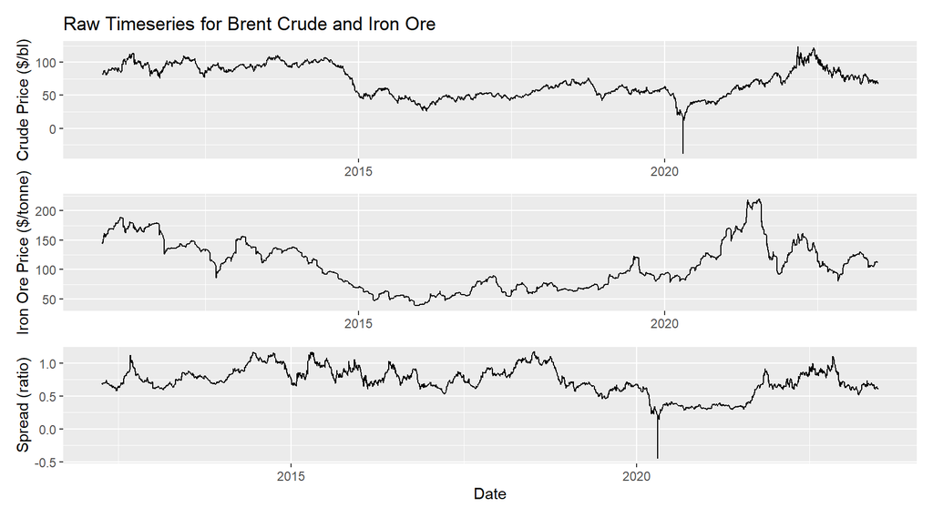

```r
p1 <- ggplot(prc_raw) +
  geom_line(aes(dte, crude)) +
  labs(title = "Raw Timeseries for Brent Crude and Iron Ore", x = NULL, y = "Crude Price ($/bl)")

p2 <- ggplot(prc_raw) +
  geom_line(aes(dte, ironore)) +
  labs(x = NULL, y = "Iron Ore Price ($/tonne)")

p3 <- prc %>%
  na.omit() %>%
  ggplot() +
  geom_line(aes(dte, spd)) +
  labs(x = "Date", y = "Spread (ratio)")

p1 / p2 / p3
```

When we scale to show the prices and spread together with smoothing we can see the spread is fairly consistent until after the big spike in prices where one diverges from the other significantly. This means the spread is not immune to the forces of the other prices so we will need to deal with high voltility either way.

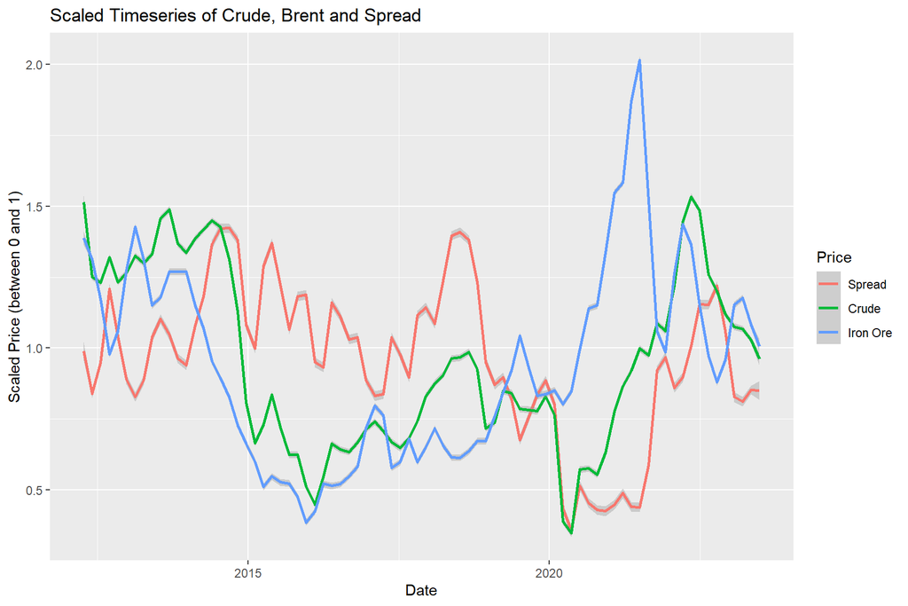

```r
prc_scale <-
  data.table(dte = prc[, dte],
             Spread = scale(prc[, spd], center = F)[, 1],
             Crude = scale(prc[["crude"]], center = F)[, 1],
             `Iron Ore` = scale(prc[["ironore"]], center = F)[, 1]) %>%
  melt(id.vars = "dte", variable.name = "Price")

ggplot(prc_scale) +
  geom_smooth(aes(dte, value, color = Price), span = 0.05, method = "loess") +
  labs(title = "Scaled Timeseries of Crude, Brent and Spread",
       y = "Scaled Price (between 0 and 1)", x = "Date")
```

### Seasonality

The price itself shows a complex seasonality but it’s fairly weak. The randomness is much higher than the seasonality. It means the forecast using the past price patterns alone. There is a good candidate in the 365 area, so what was happening a the same time last year looks to have some indication.

More importantly this yearly cycle looks deterministic which should help with prediction.

More info on seasonality types here: https://towardsdatascience.com/3-types-of-seasonality-and-how-to-detect-them-4e03f548d167

When we talk about 28, 90 that is the seasonal period that is averaged together to create the seasonal pattern. As the series is daily, the frequency per year is 365 then we divide by 28 to approximate a month. It dosnt’ have to be exact as there are many influences on seasonal patterns.

More info here: https://otexts.com/fpp2/classical-decomposition.html

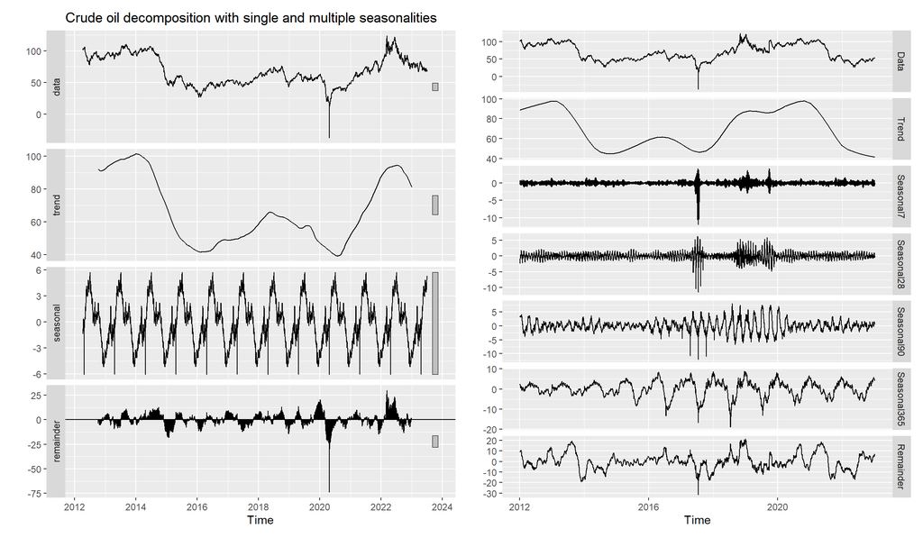

```r
# st_ts <- ts(prc[,crude], start=c(year(min(prc$dte)),month(min(prc$dte))),
#             end=c(year(max(prc$dte)),month(max(prc$dte))),frequency = c(365))

plt_ts_one <- forecast::autoplot(decompose(crude_ts)) +
  labs(title = "Crude oil decomposition with single and multiple seasonalities")
crude_msts <- forecast::msts(prc[,crude], start=c(year(min(prc$dte)),month(min(prc$dte))),
                          end=c(year(max(prc$dte)),month(max(prc$dte))),seasonal.periods = c(7, 28, 90, 365), ts.frequency = 365)

plt_ts_mult <- forecast::mstl(crude_msts, s.window = c(7)) %>% autoplot()


plt_ts_one | plt_ts_mult
```

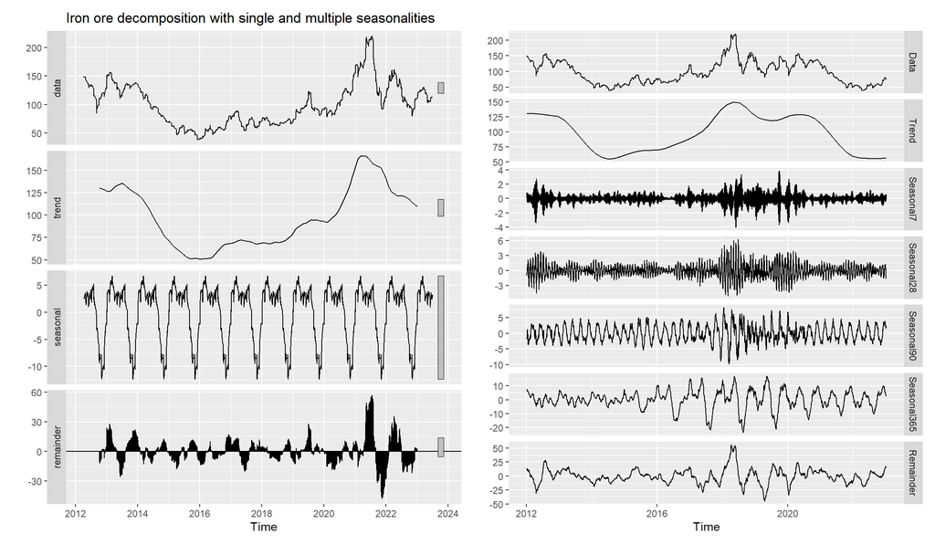

```r
# st_ts <- ts(prc[,crude], start=c(year(min(prc$dte)),month(min(prc$dte))),
#             end=c(year(max(prc$dte)),month(max(prc$dte))),frequency = c(365))

plt_ts_one <- forecast::autoplot(decompose(ironore_ts))  +
  labs(title = "Iron ore decomposition with single and multiple seasonalities")

ironore_msts <- forecast::msts(prc[,ironore], start=c(year(min(prc$dte)),month(min(prc$dte))),
                          end=c(year(max(prc$dte)),month(max(prc$dte))),seasonal.periods = c(7, 28, 90, 365), ts.frequency = 365)

plt_ts_mult <- forecast::mstl(ironore_msts, s.window = c(7)) %>% autoplot()


plt_ts_one | plt_ts_mult
```

## Statistical properties

Broadly speaking the steps are taken from this section: https://otexts.com/fpp2/arima-r.html

### ACF and PACF

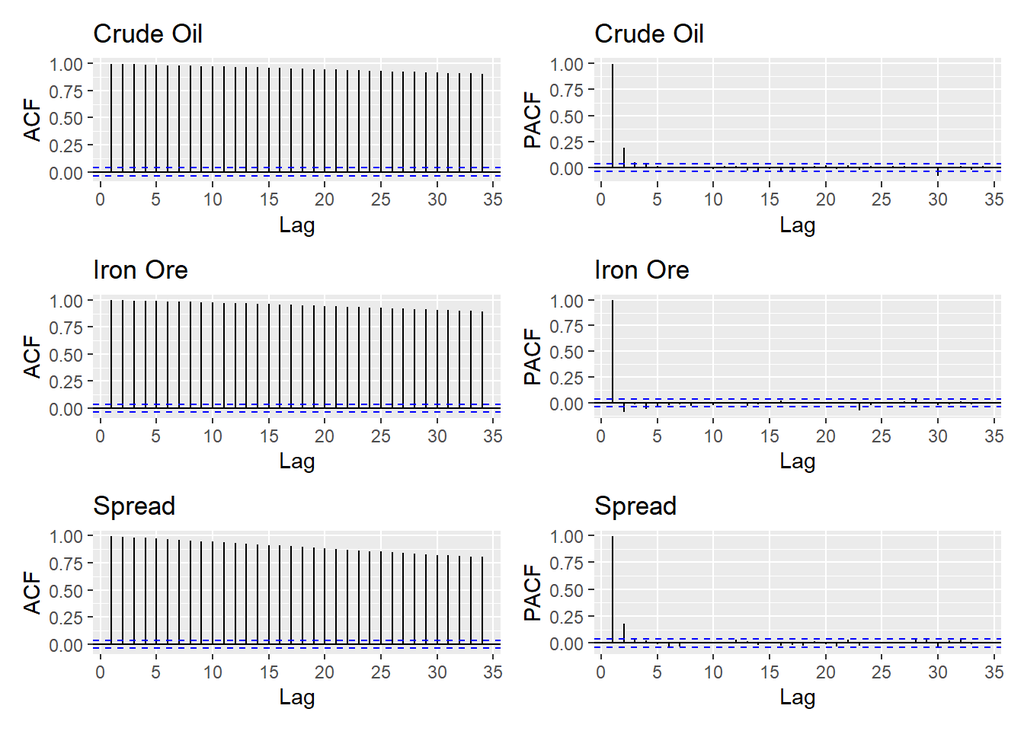

```r
(forecast::ggAcf(crude[, crude], main = "Crude Oil")  /
  forecast::ggAcf(ironore[[2]], main = "Iron Ore") /
  forecast::ggAcf(spd[[2]], main = "Spread")) |

(forecast::ggPacf(crude[[2]], main = "Crude Oil") /
   forecast::ggPacf(ironore[[2]], main = "Iron Ore") /
   forecast::ggPacf(spd[[2]], main = "Spread") )
```

### Checking Normality

The spread is the best so it might be better for making predictions.

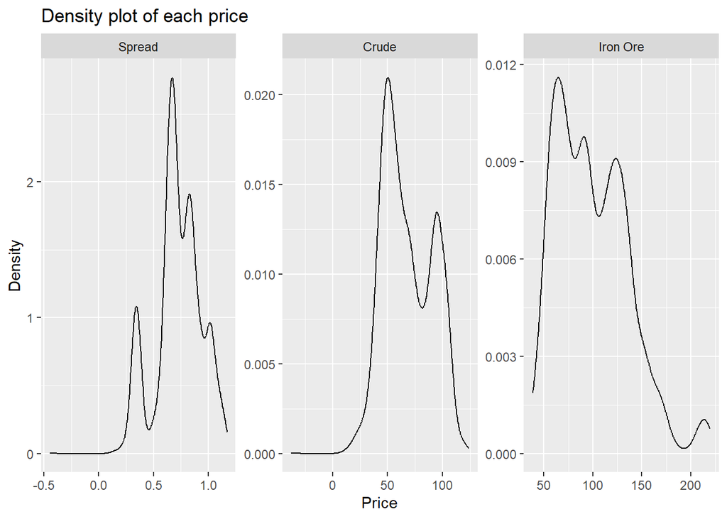

```r
prc %>%
 .[, .(dte, Spread = spd, Crude = crude, `Iron Ore` = ironore)] %>%
  melt(id.vars = "dte") %>%
ggplot() +
  #geom_histogram(aes(value)) +
  geom_density(aes(value)) +
  facet_wrap(vars(variable), scales = "free")  +
  labs(title = "Density plot of each price", x = "Price", y = "Density")
```

This is just a p-value test of the above, but it is saying the same thing. Anything < 0.01 is not normally distributed.

```r
shapiro.test(crude[[2]])
```

```
##
##  Shapiro-Wilk normality test
##
## data:  crude[[2]]
## W = 0.9604, p-value < 0.00000000000000022
```

```r
shapiro.test(ironore[[2]])
```

```
##
##  Shapiro-Wilk normality test
##
## data:  ironore[[2]]
## W = 0.95364, p-value < 0.00000000000000022
```

```r
shapiro.test(spd[[2]])
```

```
##
##  Shapiro-Wilk normality test
##
## data:  spd[[2]]
## W = 0.97027, p-value < 0.00000000000000022
```

### Checking Variance

Another problem with financial timeseries is changing variance (volatility) of the data. If variance is constantly changing it can affect predictions. Again, predictions can still be made, but it might help accuracy to reduce the variance before making predictions.

Below is a plot of standard deviation by month. This is to find any changing variance

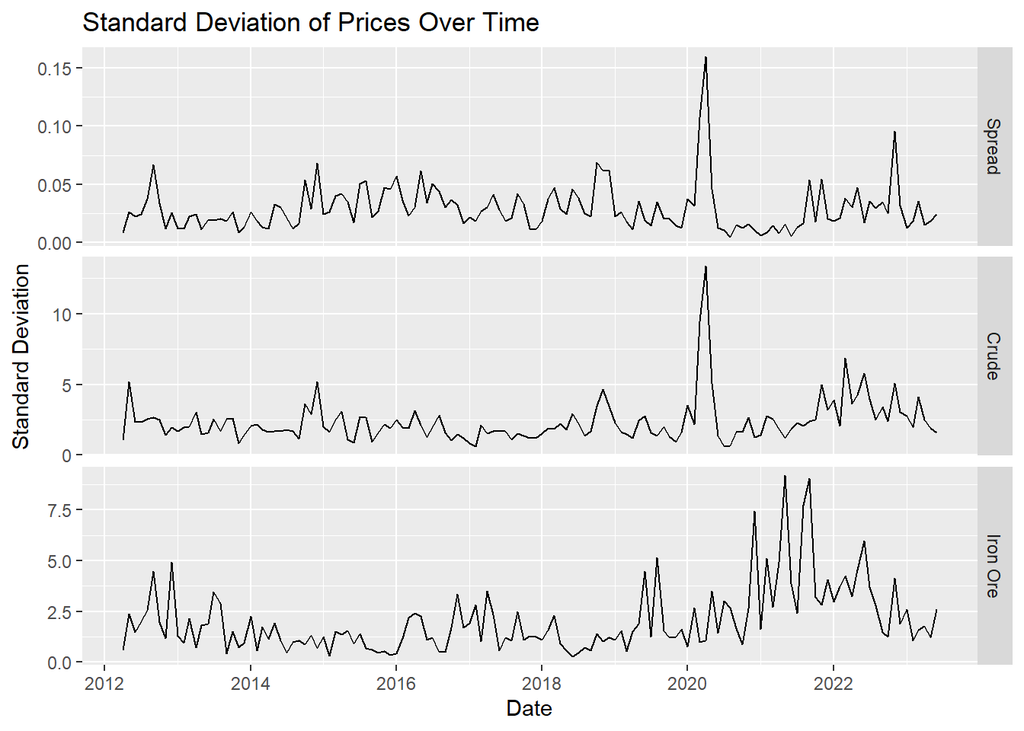

```r
prc[, .(Spread = sd(spd),
        Crude = sd(crude),
        `Iron Ore` = sd(ironore)), by = floor_date(dte, "month")] %>%
  setnames(old = "floor_date", new = "Mth") %>%
  melt("Mth") %>%
  ggplot() +
  geom_line(aes(Mth, value)) +
  facet_grid(rows = vars(variable), scales = "free_y") +
  labs(title = "Standard Deviation of Prices Over Time", x = "Date", y = "Standard Deviation")
```

This plot uses the changepoint package which uses a different measure to find the change in variance.

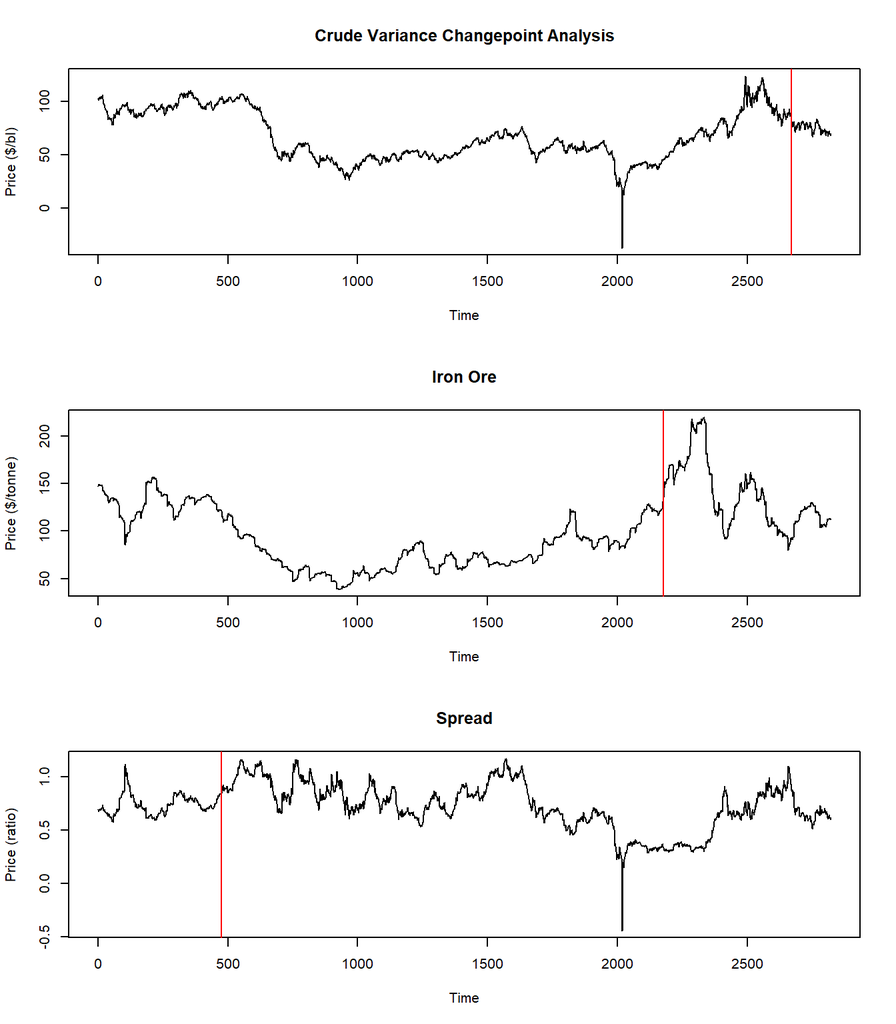

```r
par(mfrow = c(3, 1))

crude_var <- changepoint::cpt.var(prc[, crude])

plot(crude_var, main = "Crude Variance Changepoint Analysis", ylab = "Price ($/bl)")

ironore_var <- changepoint::cpt.var(prc[, ironore])

plot(ironore_var, main = "Iron Ore", ylab = "Price ($/tonne)")

spd_var <- changepoint::cpt.var(prc[, spd], mu = mean(prc[, spd]), know.mean = T)

plot(spd_var, main = "Spread", ylab = "Price (ratio)")
```

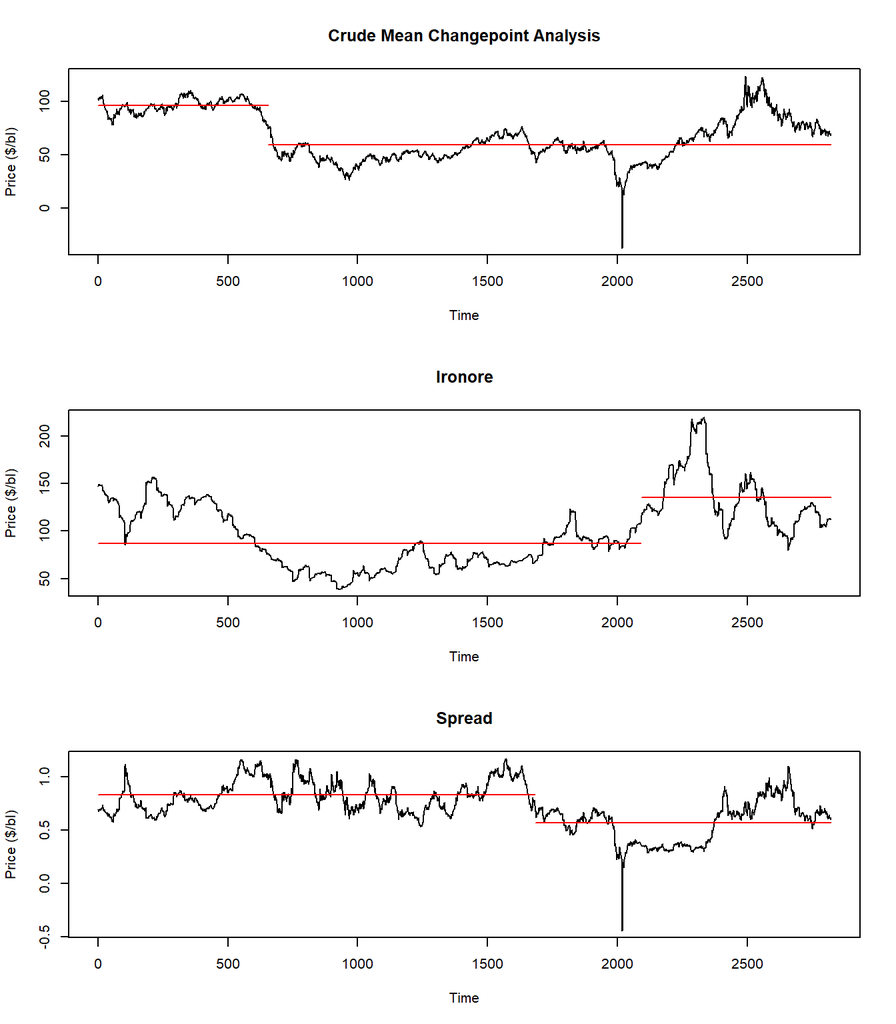

```r
par(mfrow = c(3, 1))

crude_var <- changepoint::cpt.mean(prc[, crude])

plot(crude_var, main = "Crude Mean Changepoint Analysis", ylab = "Price ($/bl)")

ironore_var <- changepoint::cpt.mean(prc[, ironore])

plot(ironore_var, main = "Ironore", ylab = "Price ($/bl)")

spd_var <- changepoint::cpt.mean(prc[, spd])

plot(spd_var, main = "Spread", ylab = "Price ($/bl)")
```

In conclusion the variance does change. Again, this is normal for financial data which tend to go though periods where it is stable and more volatile.

## Explanatory Feature

### Correlation

It was mentioned that 0417 can be used to explain the activity of 0119. The thing that is worth bearing in mind here is they could be correlated this doesn’t mean one is good a predicting the other. Most of the forecast heavy lifting is done through analysing the price itself and features that are predictive. Things like the seasonality.

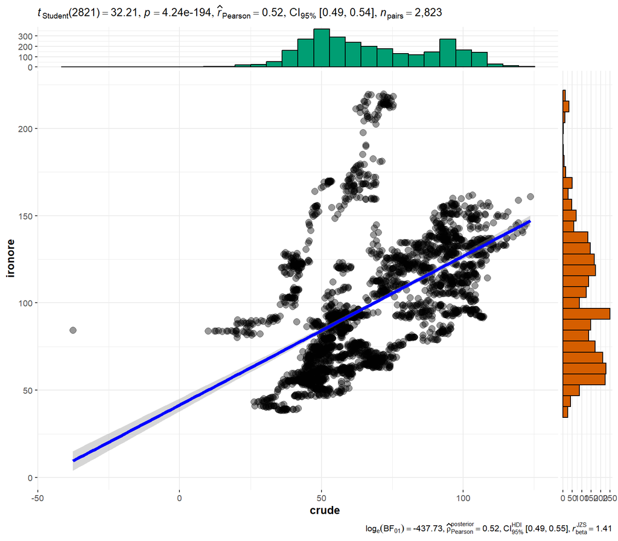

```r
ggstatsplot::ggscatterstats(data = prc, x = crude, y = ironore)
```

### Time Shifting

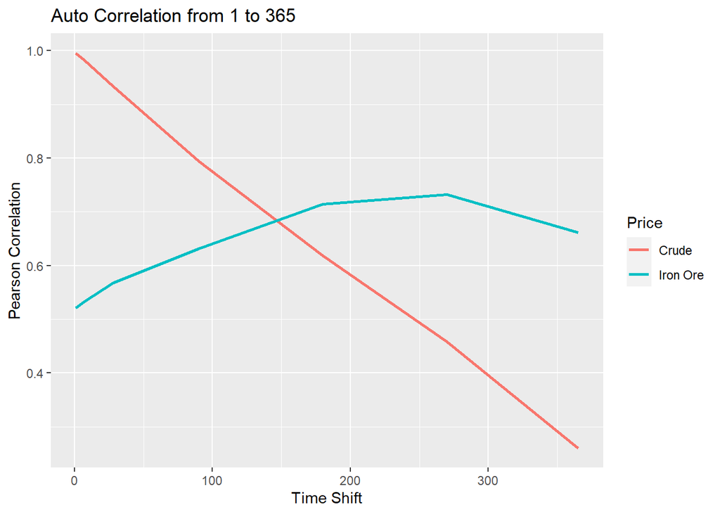

```r
prc_cor_dt %>%
.[, .(Price = prc, Shift = sft, Correlation = corr.crude)] %>%
.[Price == "crude", Price := "Crude"] %>%
.[Price == "ironore", Price := "Iron Ore"] %>%
ggplot() +
  geom_line(aes(as.numeric(Shift), Correlation, color = Price), linewidth = 1) +
  labs(title = "Auto Correlation from 1 to 365", x = "Time Shift", y = "Pearson Correlation")
```

## Inital Modelling

At this point you can put the values straight into auto.arima and see how it performs. This is because the forecast package can do most of the work for you in the modelling process or at least find a best guess.

I take off the last 365 points (test set) and then test the forecast against this test set. The lower the RMSE (error rate) the better. Bear in mind it is scale dependent so the error rate cannot be compared across the crude and spread models.

I have added the residuals (difference between observed and predicted) to see how the model performs. For the timeline we want no discernible pattern.

Finally the historgram is the distribution of the residuals, we essentially want it to center around 0 and be even on both sides.

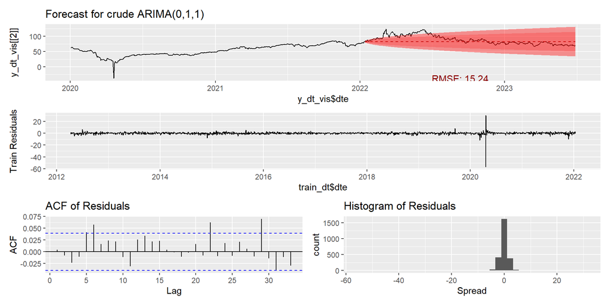

```r
train_test_split_forecast <- function(y_dt, test_points = 365, level = c(80, 95), auto = T, order = c(0,0,0), seasonal = c(0,0,0),
                                      xreg_train = NULL, xreg_test = NULL) {

    train <- y_dt[1:(nrow(y_dt) - test_points)][[2]]
    test <- y_dt[(nrow(y_dt) - test_points + 1):nrow(y_dt)][[2]]
    train_dtes <- y_dt[1:(nrow(y_dt) - test_points), dte]
    test_dtes <- y_dt[(nrow(y_dt) - test_points):nrow(y_dt), dte][-1]

    if (!is.null(xreg_train)) {
      xreg_train <- matrix(xreg_train[1:(nrow(xreg_train) - test_points)][[2]])

      if (auto) {
        mdl <- forecast::auto.arima(train, xreg = xreg_train)
      } else {
        mdl <- forecast::Arima(train, order = order, seasonal = seasonal, xreg = xreg_train)
      }

      fcst <- forecast::forecast(mdl, h = test_points, level = level, xreg = xreg_test)

    } else {

      if (auto) {
        mdl <- forecast::auto.arima(train)
      } else {
        mdl <- forecast::Arima(train, order = order, seasonal = seasonal)
      }

      fcst <- forecast::forecast(mdl, h = test_points, level = level)

    }

    fcst_dt <- data.table(dte = test_dtes, mn = fcst$mean, lo1 = fcst$lower[,1], lo2 = fcst$lower[,2],
                          hi1 = fcst$upper[,1], hi2 = fcst$upper[,2], fcst_obs = test)

    train_dt <- data.table(dte = train_dtes, y_val = train)

    return(list(fcst_dt, fcst, train_dt))

}

train_test_split_forecast_ts <- function(y_dt, test_points = 365,
                                         level = c(80, 95), auto = T, order = c(0,0,0), seasonal = c(0,0,0),
                                      xreg_train = NULL, xreg_test = NULL) {

    train_dtes <- y_dt[1:(nrow(y_dt) - test_points), dte]
    test_dtes <- y_dt[(nrow(y_dt) - test_points):nrow(y_dt), dte][-1]

    train <- ts(y_dt[dte %in% train_dtes][[2]], start=c(year(train_dtes[1]),as.numeric(format(train_dtes[1], "%j"))),
              frequency = 365)

    test <- ts(y_dt[dte %in% test_dtes][[2]], start=c(year(test_dtes[1]),as.numeric(format(test_dtes[1], "%j"))),
                frequency = 365)

    if (!is.null(xreg_train)) {
      xreg_train <- matrix(xreg_train[1:(nrow(xreg_train) - test_points)][[2]])

      if (auto) {
        mdl <- forecast::auto.arima(train, xreg = xreg_train)
      } else {
        mdl <- forecast::Arima(train, order = order, seasonal = seasonal, xreg = xreg_train)
      }

      fcst <- forecast::forecast(mdl, h = test_points, level = level, xreg = xreg_test)

    } else {

      if (auto) {
        mdl <- forecast::auto.arima(train)
      } else {
        mdl <- forecast::Arima(train, order = order, seasonal = seasonal)
      }

      fcst <- forecast::forecast(mdl, h = test_points, level = level)

    }

    fcst <- forecast::forecast(mdl, h = test_points, level = level, xreg = xreg_test)

    fcst_dt <- data.table(dte = test_dtes, mn = fcst$mean, lo1 = fcst$lower[,1], lo2 = fcst$lower[,2],
                          hi1 = fcst$upper[,1], hi2 = fcst$upper[,2], fcst_obs = test)

    train_dt <- data.table(dte = train_dtes, y_val = train)

    return(list(fcst_dt, fcst, train_dt))

}

plot_fcst_resid <- function(y_dt, fcst_dt, fcst, train_dt, vis_start_date = lubridate::as_date("1900-01-01")) {

    acc <- forecast::accuracy(as.numeric(y_dt[dte %chin% fcst_dt[, dte]][[2]]), as.numeric(fcst_dt$mn))

    y_dt_vis <- y_dt[dte >= vis_start_date]
    fcst_dt_vis <- fcst_dt[dte >= vis_start_date]
    train_dt_vis <- train_dt[dte >= vis_start_date]

    p1 <- ggplot() +
    geom_line(aes(y_dt_vis$dte, y_dt_vis[[2]])) +
    geom_line(aes(fcst_dt_vis$dte, fcst_dt_vis$mn), linetype = "dashed", color = "darkred") +
    geom_ribbon(aes(fcst_dt_vis$dte, ymin = fcst_dt_vis$lo1, ymax = fcst_dt_vis$hi1), alpha = 0.2, fill = "red") +
    geom_ribbon(aes(fcst_dt_vis$dte, ymin = fcst_dt_vis$lo2, ymax = fcst_dt_vis$hi2), alpha = 0.4, fill = "red") +
        geom_text() +
        annotate(
          "text", label = paste0("RMSE: ", round(acc[2],2)),
          x = lubridate::as_date(max(y_dt_vis[(length(y_dt_vis[, dte])-200), dte])),
          y = min(y_dt_vis[[2]]), size = 4, colour = "darkred"
        ) +
    labs(title = paste0("Forecast for ", names(y_dt_vis)[2], " ", fcst$method))

  p2 <- ggplot() +
        geom_line(aes(x = train_dt$dte, y = as.numeric(fcst$residuals))) +
    labs(y = "Train Residuals")

  p3 <- forecast::ggAcf(as.numeric(fcst$residuals)) +
    labs(title = "ACF of Residuals")

  p4 <- ggplot() +
    geom_histogram(aes(as.numeric(fcst$residuals)), bins = 40) +
    labs(title = "Histogram of Residuals", x = "Spread")

    p1 / p2 / (p3 | p4)

}

fcst_list <- train_test_split_forecast(y_dt = crude, test_points = test_points, xreg_train = NULL)

plot_fcst_resid(y_dt = crude, fcst_dt = fcst_list[[1]], fcst = fcst_list[[2]],
                train_dt = fcst_list[[3]], vis_start_date = lubridate::as_date("2020-01-01"))
```

When testing the spread with the inversion, it doesn’t seem to help much.

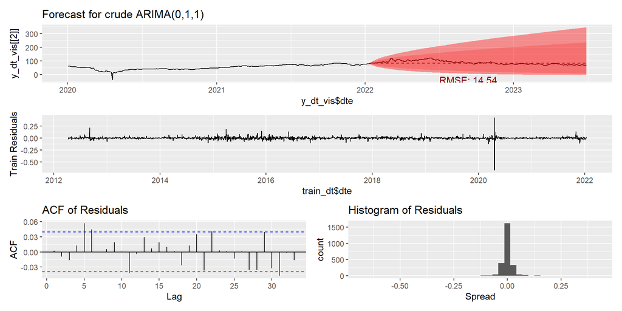

```r
fcst_list_spd <- train_test_split_forecast(y_dt = spd, test_points = test_points)

fcst_list_ironore <- train_test_split_forecast(y_dt = ironore, test_points = test_points)

fcst_dt_invert <- fcst_list_spd[[1]] %>%
  copy()

for (col in 2:ncol(fcst_list_ironore[[1]])) {

  fcst_dt_invert[[col]] <- fcst_dt_invert[[col]] * fcst_list_ironore[[1]][[col]]

}

plot_fcst_resid(y_dt = crude, fcst_dt = fcst_dt_invert, fcst = fcst_list_spd[[2]],
                train_dt = fcst_list_spd[[3]], vis_start_date = lubridate::as_date("2020-01-01"))
```

## Transformation

To try to deal with the changing variance and normality that was shown to be the case above we are going to transform the data using a Box-cox.

```r
#https://www.css.cornell.edu/faculty/dgr2/_static/files/R_html/Transformations.html

crude_comp_lm <- lm(crude$crude ~ ironore$ironore)

summary(crude_comp_lm)
```

```
##
## Call:
## lm(formula = crude$crude ~ ironore$ironore)
##
## Residuals:
##      Min       1Q   Median       3Q      Max
## -100.712  -10.924   -1.095   14.001   41.731
##
## Coefficients:
##                  Estimate Std. Error t value            Pr(>|t|)
## (Intercept)     36.456132   1.038078   35.12 <0.0000000000000002 ***
## ironore$ironore  0.315356   0.009791   32.21 <0.0000000000000002 ***
## ---
## Signif. codes:  0 '***' 0.001 '**' 0.01 '*' 0.05 '.' 0.1 ' ' 1
##
## Residual standard error: 19.11 on 2821 degrees of freedom
## Multiple R-squared:  0.2689, Adjusted R-squared:  0.2686
## F-statistic:  1037 on 1 and 2821 DF,  p-value: < 0.00000000000000022
```

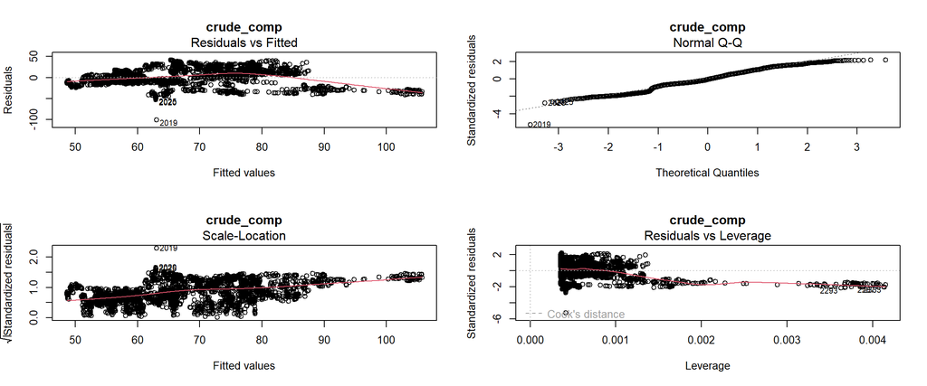

```r
par(mfrow=c(2,2))
plot(crude_comp_lm, main = "crude_comp")
```

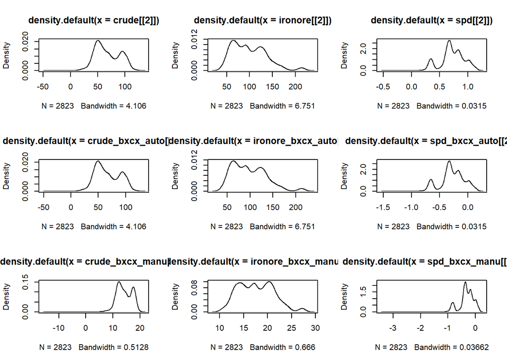

```r
lambda = 0.5

lambda_crude <- forecast::BoxCox.lambda(crude)
crude_bxcx_auto <- data.table(dte = crude[, dte], crude = forecast::BoxCox(crude[[2]], lambda = lambda_crude))
crude_bxcx_manu <- data.table(dte = crude[, dte], crude = forecast::BoxCox(crude[[2]], lambda = lambda))

lambda_ironore <- forecast::BoxCox.lambda(ironore)
ironore_bxcx_auto <- data.table(dte = ironore[, dte], ironore = forecast::BoxCox(ironore[[2]], lambda = lambda_ironore))
ironore_bxcx_manu <- data.table(dte = ironore[, dte], ironore = forecast::BoxCox(ironore[[2]], lambda = lambda))

lambda_spd <- forecast::BoxCox.lambda(spd)
spd_bxcx_auto <- data.table(dte = spd[, dte], spd = forecast::BoxCox(spd[[2]], lambda = lambda_spd))
spd_bxcx_manu <- data.table(dte = spd[, dte], spd = forecast::BoxCox(spd[[2]], lambda = lambda))

# crude_diff <- diff(crude, lag = 1)
# ironore_diff <- diff(ironore, lag = 1)
# spd_diff <- diff(spd, lag = 1)

par(mfrow = c(3, 3))
plot(density(crude[[2]]))
plot(density(ironore[[2]]))
plot(density(spd[[2]]))

plot(density(crude_bxcx_auto[[2]]))
plot(density(ironore_bxcx_auto[[2]]))
plot(density(spd_bxcx_auto[[2]]))

plot(density(crude_bxcx_manu[[2]]))
plot(density(ironore_bxcx_manu[[2]]))
plot(density(spd_bxcx_manu[[2]]))
```

```r
#spd_bxcx_inv <- forecast::InvBoxCox(spd_bxcx, lambda = 0.5)
```

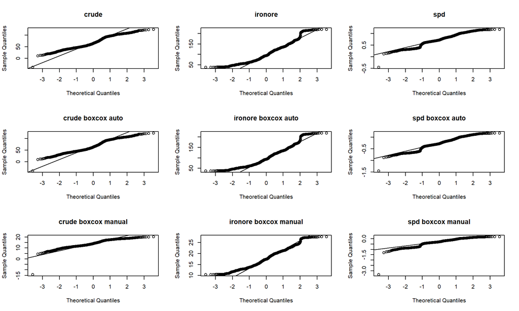

```r
par(mfrow = c(3, 3))
qqnorm(crude[[2]], main = "crude")
qqline(crude[[2]])
qqnorm(ironore[[2]], main = "ironore")
qqline(ironore[[2]])
qqnorm(spd[[2]], main = "spd")
qqline(spd[[2]])

qqnorm(crude_bxcx_auto[[2]], main = "crude boxcox auto")
qqline(crude_bxcx_auto[[2]])
qqnorm(ironore_bxcx_auto[[2]], main = "ironore boxcox auto")
qqline(ironore_bxcx_auto[[2]])
qqnorm(spd_bxcx_auto[[2]], main = "spd boxcox auto")
qqline(spd_bxcx_auto[[2]])

qqnorm(crude_bxcx_manu[[2]], main = "crude boxcox manual")
qqline(crude_bxcx_manu[[2]])
qqnorm(ironore_bxcx_manu[[2]], main = "ironore boxcox manual")
qqline(ironore_bxcx_manu[[2]])
qqnorm(spd_bxcx_manu[[2]], main = "spd boxcox manual")
qqline(spd_bxcx_manu[[2]])
```

```r
crude_bxcx <- crude_bxcx_auto
ironore_bxcx <- ironore_bxcx_auto
spd_bxcx <- spd_bxcx_auto
```

```r
# fcst_arima <- function(y, auto = T, order = c(0,0,0), seasonal = c(0,0,0)) {
#
#   if (auto) {
#
#     mdl <- forecast::auto.arima(y)
#
#   } else {
#
#     mdl <- forecast::Arima(y, order = order, seasonal = seasonal)
#
#   }
#
#   fcst <- forecast::forecast(mdl, h = test_points)
#
#   acc <- forecast::accuracy(y[(nrow(prc) - test_points):nrow(prc)], fcst$mean)
#
#   print(mdl)
#
#   print(acc)
#
#   print(forecast::checkresiduals(mdl))
#
#   print(forecast::autoplot(fcst))
#
# }
#
#
# fcst_arima(crude)
```

## Auto with Transformation

### Transformed crude Forecast

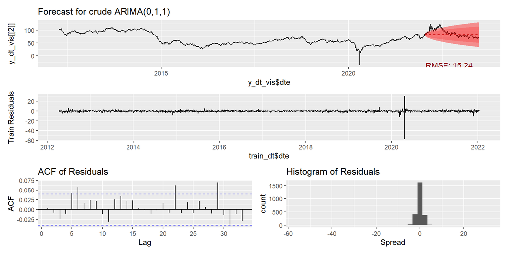

```r
fcst_list <- train_test_split_forecast(y_dt = crude_bxcx_auto)

fcst_dt_invert <- fcst_list[[1]] %>%
  copy()%>%
  .[, (cols) := lapply(.SD, function(x){forecast::InvBoxCox(x, lambda = lambda_crude)}), .SDcols = cols]

plot_fcst_resid(y_dt = crude, fcst_dt = fcst_dt_invert, fcst = fcst_list[[2]], train_dt = fcst_list[[3]])
```

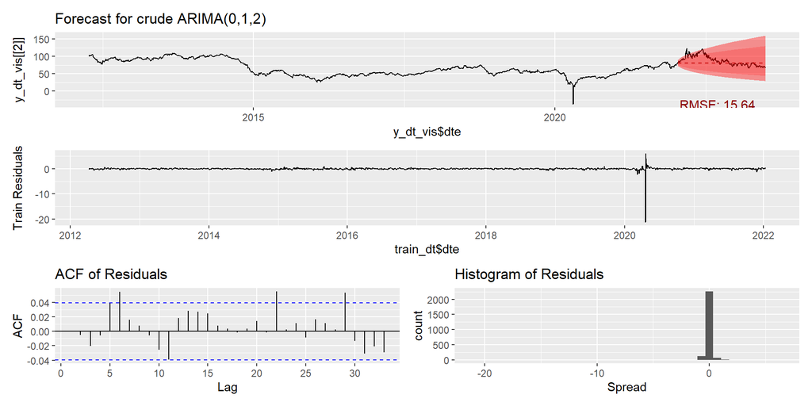

```r
fcst_list <- train_test_split_forecast(y_dt = crude_bxcx_manu)

fcst_dt_invert <- fcst_list[[1]] %>%
  copy()%>%
  .[, (cols) := lapply(.SD, function(x){forecast::InvBoxCox(x, lambda = lambda)}), .SDcols = cols]

plot_fcst_resid(y_dt = crude, fcst_dt = fcst_dt_invert, fcst = fcst_list[[2]], train_dt = fcst_list[[3]])
```

### Transformed Spread Forecast

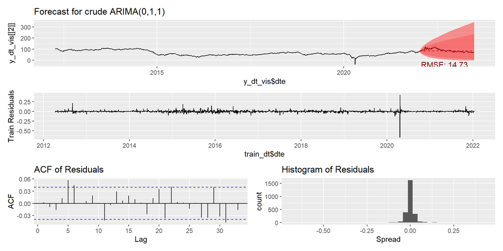

```r
fcst_list_spd <- train_test_split_forecast(y_dt = spd_bxcx_auto)

fcst_list_ironore <- train_test_split_forecast(y_dt = ironore_bxcx_auto, test_points = test_points)

fcst_dt_invert <- fcst_list_spd[[1]] %>%
  copy() %>%
  .[, (cols) := lapply(.SD, function(x){forecast::InvBoxCox(x, lambda = lambda_spd)}), .SDcols = cols]

for (col in 2:ncol(fcst_list_ironore[[1]])) {

  fcst_dt_invert[[col]] <- fcst_dt_invert[[col]] * fcst_list_ironore[[1]][[col]]

}

plot_fcst_resid(y_dt = crude, fcst_dt = fcst_dt_invert, fcst = fcst_list_spd[[2]], train_dt = fcst_list_spd[[3]])
```

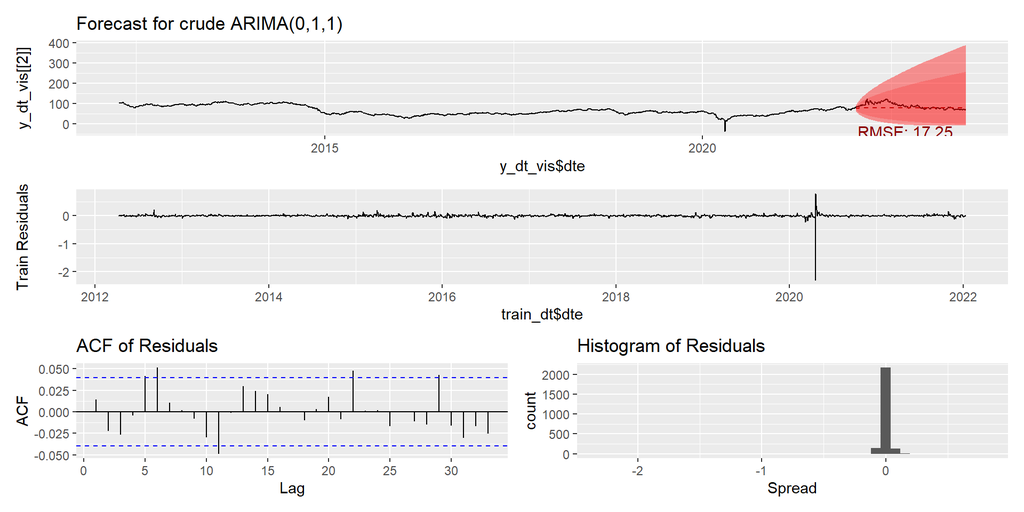

```r
fcst_list_spd <- train_test_split_forecast(y_dt = spd_bxcx_manu)

fcst_list_ironore <- train_test_split_forecast(y_dt = ironore_bxcx_auto, test_points = test_points)

fcst_dt_invert <- fcst_list_spd[[1]] %>%
  copy() %>%
  .[, (cols) := lapply(.SD, function(x){forecast::InvBoxCox(x, lambda = lambda_spd)}), .SDcols = cols]

for (col in 2:ncol(fcst_list_ironore[[1]])) {

  fcst_dt_invert[[col]] <- fcst_dt_invert[[col]] * fcst_list_ironore[[1]][[col]]

}

plot_fcst_resid(y_dt = crude, fcst_dt = fcst_dt_invert, fcst = fcst_list_spd[[2]], train_dt = fcst_list_spd[[3]])
```

In conclusion, the BoxCox transformation doesn’t make much difference to the prediction capability.

## Auto With Diff

It was mentioned earlier that there are auto correlations in the data, it might help to differnce the data first. This just subtracting one value from another to make the data stationary (without trends).

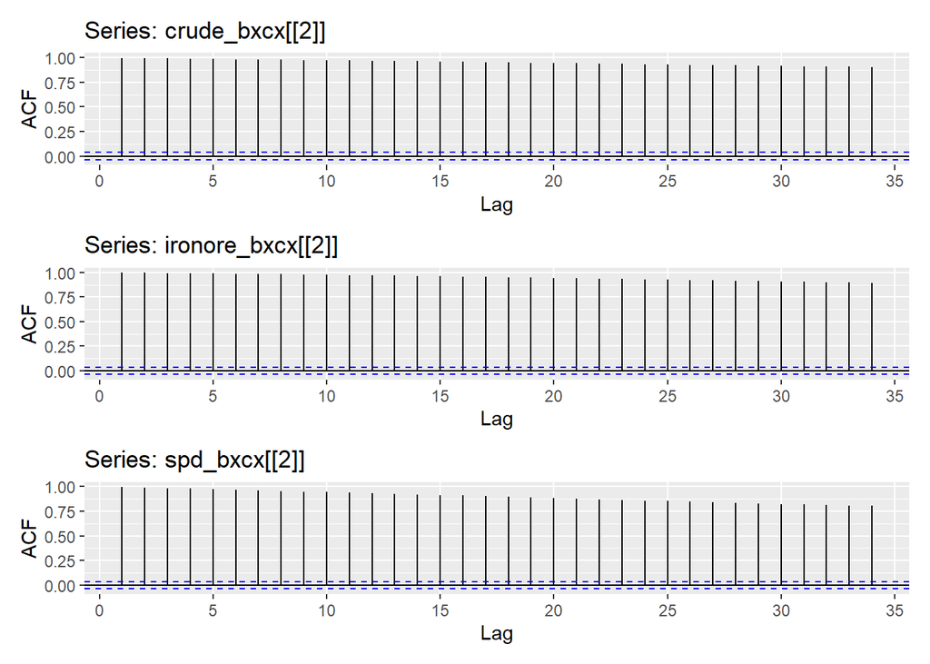

```r
forecast::ggAcf(crude_bxcx[[2]]) / forecast::ggAcf(ironore_bxcx[[2]]) / forecast::ggAcf(spd_bxcx[[2]])
```

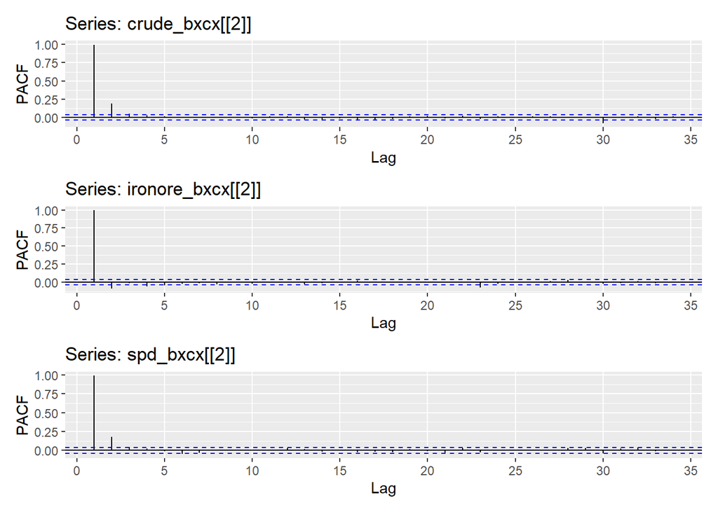

```r
forecast::ggPacf(crude_bxcx[[2]]) / forecast::ggPacf(ironore_bxcx[[2]]) / forecast::ggPacf(spd_bxcx[[2]])
```

So by far the strongest auto correlation is 1, so we will diff 1.

If interested in what these plots mean more info here:

https://towardsdatascience.com/interpreting-acf-and-pacf-plots-for-time-series-forecasting-af0d6db4061c

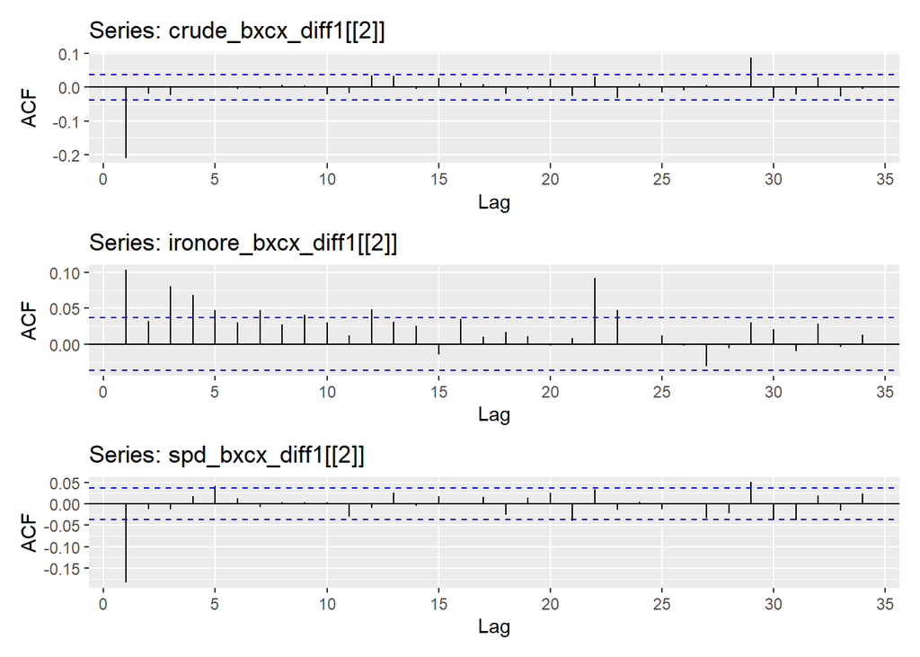

```r
crude_bxcx_diff1 <- data.table(dte = crude_bxcx[, dte][-1], crude = diff(crude_bxcx[[2]], lag = 1))
ironore_bxcx_diff1 <- data.table(dte = ironore_bxcx[, dte][-1], ironore = diff(ironore_bxcx[[2]], lag = 1))
spd_bxcx_diff1 <- data.table(dte = spd_bxcx[, dte][-1], spd = diff(spd_bxcx[[2]], lag = 1))

forecast::ggAcf(crude_bxcx_diff1[[2]]) / forecast::ggAcf(ironore_bxcx_diff1[[2]]) / forecast::ggAcf(spd_bxcx_diff1[[2]])
```

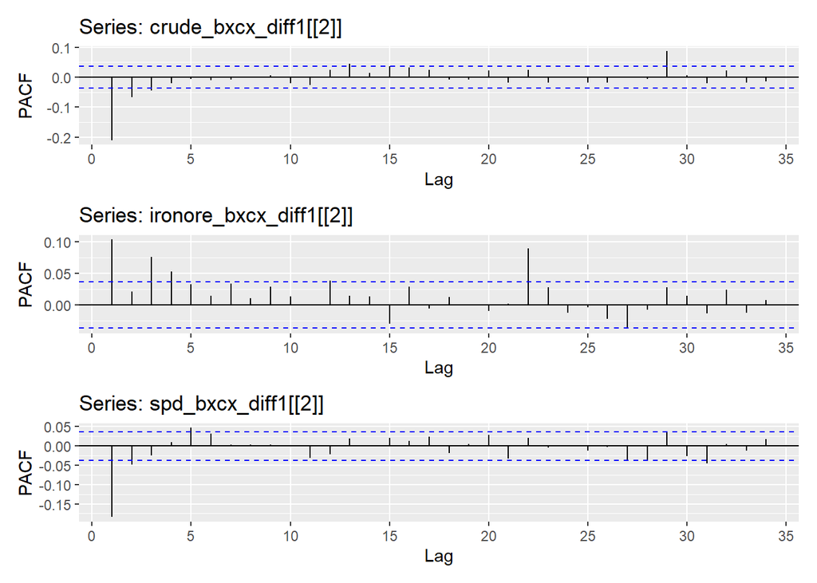

```r
forecast::ggPacf(crude_bxcx_diff1[[2]]) / forecast::ggPacf(ironore_bxcx_diff1[[2]]) / forecast::ggPacf(spd_bxcx_diff1[[2]])
```

```r
# spd_bxcx <- forecast::BoxCox(spd, lambda = 0.5)
# spd_bxcx_inv <- forecast::InvBoxCox(spd_bxcx, lambda = 0.5)
#
# spd[1:10]
# spd_bxcx[1:10]
# spd_bxcx_inv[1:10]
```

```r
# crude_bxcx_first_val <- crude_bxcx[1, crude]
#
# fcst_list <- train_test_split_forecast(y_dt = crude_bxcx_diff1)
#
# crude_bxcx_inv <- data.table(dte = crude_bxcx[, dte], crude = diffinv(crude_bxcx_diff1[[2]], xi = crude_bxcx_first_val))
#
# crude_bxcx_fcst_first_val <- crude_bxcx_inv[dte == fcst_list[[1]][1, dte], crude]
#
# fcst_dt_invert <- fcst_list[[1]] %>%
#   copy() %>%
#   .[, mn := diffinv(mn, xi = crude_bxcx_fcst_first_val, lag = 1)[-1]] %>%
#   .[, lo1 := mn + lo1] %>%
#   .[, lo2 := mn + lo2] %>%
#   .[, hi1 := mn + hi1] %>%
#   .[, hi2 := mn + hi2] %>%
#   .[, fcst_obs := crude_bxcx_fcst_first_val + fcst_obs] %>%
#   .[, (cols) := lapply(.SD, function(x){forecast::InvBoxCox(x, lambda = lambda_crude)}), .SDcols = cols]
#
# plot_fcst_resid(y_dt = crude, fcst_dt = fcst_dt_invert, fcst = fcst_list[[2]], train_dt = fcst_list[[3]])
```

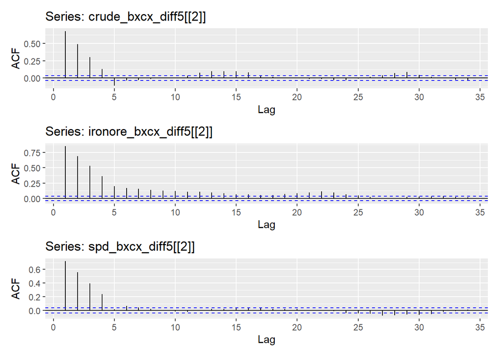

```r
crude_bxcx_diff5 <- data.table(dte = crude_bxcx[6:nrow(crude_bxcx), dte], crude = diff(crude_bxcx[[2]], lag = 5))
ironore_bxcx_diff5 <- data.table(dte = ironore_bxcx[6:nrow(crude_bxcx), dte], crude = diff(ironore_bxcx[[2]], lag = 5))
spd_bxcx_diff5 <- data.table(dte = spd_bxcx[6:nrow(crude_bxcx), dte], crude = diff(spd_bxcx[[2]], lag = 5))

forecast::ggAcf(crude_bxcx_diff5[[2]]) / forecast::ggAcf(ironore_bxcx_diff5[[2]]) / forecast::ggAcf(spd_bxcx_diff5[[2]])
```

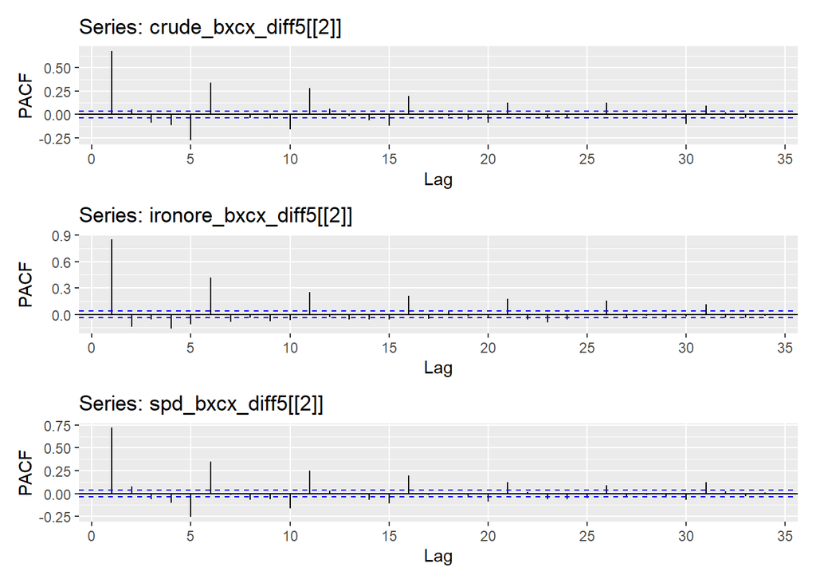

```r
forecast::ggPacf(crude_bxcx_diff5[[2]]) / forecast::ggPacf(ironore_bxcx_diff5[[2]]) / forecast::ggPacf(spd_bxcx_diff5[[2]])
```

We can double diff as well. In this case however, it doesnt seem to help.

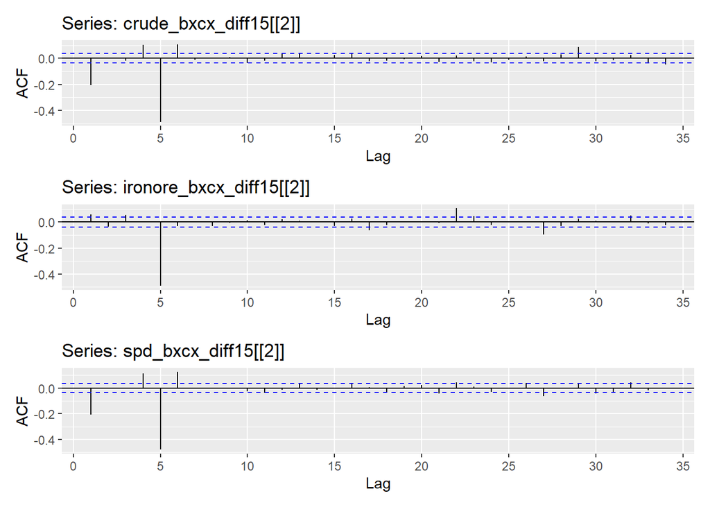

```r
crude_bxcx_diff15 <- data.table(dte = crude_bxcx[6:nrow(crude_bxcx_diff1), dte], crude = diff(crude_bxcx_diff1[[2]], lag = 5))
ironore_bxcx_diff15 <- data.table(dte = ironore_bxcx[6:nrow(crude_bxcx_diff1), dte], crude = diff(ironore_bxcx_diff1[[2]], lag = 5))
spd_bxcx_diff15 <- data.table(dte = spd_bxcx[6:nrow(crude_bxcx_diff1), dte], crude = diff(spd_bxcx_diff1[[2]], lag = 5))

forecast::ggAcf(crude_bxcx_diff15[[2]]) / forecast::ggAcf(ironore_bxcx_diff15[[2]]) / forecast::ggAcf(spd_bxcx_diff15[[2]])
```

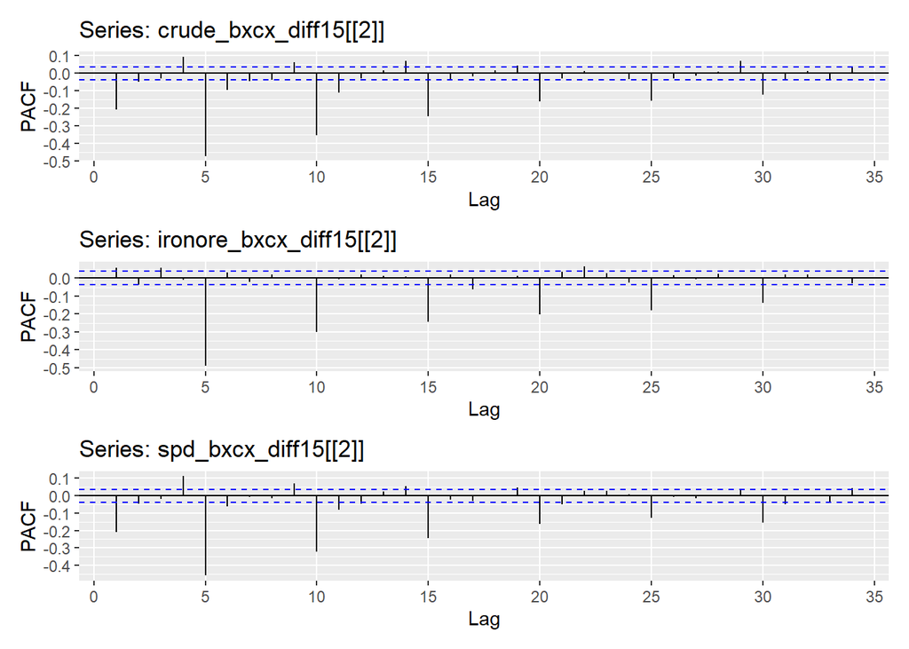

```r
forecast::ggPacf(crude_bxcx_diff15[[2]]) / forecast::ggPacf(ironore_bxcx_diff15[[2]]) / forecast::ggPacf(spd_bxcx_diff15[[2]])
```

### Diff Modelling

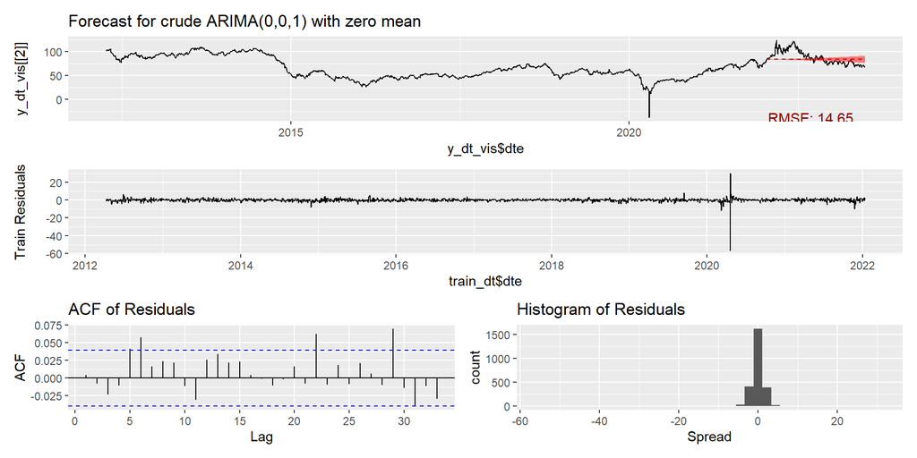

```r
fcst_bxcx_diff <- function(y_dt, y_dt_diff, y_dt_bxcx, lambda, lag_order = 1, diff_invert_hilo = FALSE, hilo_simulate_adjust = 1,
                           auto = T, order = c(0,0,0), seasonal = c(0,0,0), vis_start_date = lubridate::as_date("1990-01-01"),
                           test_points = 365) {

  fcst_list <- train_test_split_forecast(y_dt = y_dt_diff, auto = auto, order = order,
                                         seasonal = seasonal, test_points = test_points)

  crude_bxcx_first_val <- y_dt_bxcx[1:lag_order][[2]]

  crude_bxcx_inv <- data.table(dte = y_dt_bxcx[, dte], crude = diffinv(y_dt_diff[[2]],                                                                           xi = crude_bxcx_first_val, lag = lag_order))

  crude_bxcx_fcst_first_val <- crude_bxcx_inv[dte %in% fcst_list[[1]]$dte][1:lag_order][[2]]

  if (diff_invert_hilo) {

    fcst_dt_invert <- fcst_list[[1]] %>%
      copy() %>%
      .[, mn := diffinv(mn, xi = crude_bxcx_fcst_first_val, lag = lag_order)[(lag_order + 1):(test_points + lag_order)]] %>%
      .[, lo1 := diffinv(lo1, xi = crude_bxcx_fcst_first_val, lag = lag_order)[(lag_order + 1):(test_points + lag_order)]] %>%
      .[, lo2 := diffinv(lo2, xi = crude_bxcx_fcst_first_val, lag = lag_order)[(lag_order + 1):(test_points + lag_order)]] %>%
      .[, hi1 := diffinv(hi1, xi = crude_bxcx_fcst_first_val, lag = lag_order)[(lag_order + 1):(test_points + lag_order)]] %>%
      .[, hi2 := diffinv(hi2, xi = crude_bxcx_fcst_first_val, lag = lag_order)[(lag_order + 1):(test_points + lag_order)]] %>%
      .[, fcst_obs := diffinv(fcst_obs, xi = crude_bxcx_fcst_first_val,
                              lag = lag_order)[(lag_order + 1):(test_points + lag_order)]] %>%
      .[, (cols) := lapply(.SD, function(x){forecast::InvBoxCox(x, lambda = lambda)}), .SDcols = cols]

  } else {
      fcst_dt_invert <- fcst_list[[1]] %>%
        copy() %>%
        .[, mn := diffinv(mn, xi = crude_bxcx_fcst_first_val, lag = lag_order)[(lag_order + 1):(test_points + lag_order)]] %>%
        .[, lo1 := min(mn) + min(lo1) * (hilo_simulate_adjust*(.I/max(.I))+((.I/max(.I))^2))] %>%
        .[, lo2 := min(mn) + min(lo2) * (hilo_simulate_adjust*(.I/max(.I))+((.I/max(.I))^2))] %>%
        .[, hi1 := max(mn) + max(hi1) * (hilo_simulate_adjust*(.I/max(.I))+((.I/max(.I))^2))] %>%
        .[, hi2 := max(mn) + max(hi2) * (hilo_simulate_adjust*(.I/max(.I))+((.I/max(.I))^2))] %>%
        .[, fcst_obs := diffinv(fcst_obs, xi = crude_bxcx_fcst_first_val,
                                lag = lag_order)[(lag_order + 1):(test_points + lag_order)]] %>%
        .[, (cols) := lapply(.SD, function(x){forecast::InvBoxCox(x, lambda = lambda)}), .SDcols = cols]
  }

  plot_fcst_resid(y_dt = y_dt, fcst_dt = fcst_dt_invert, fcst = fcst_list[[2]],
                  train_dt = fcst_list[[3]], vis_start_date  = vis_start_date)
}

fcst_bxcx_diff(y_dt = crude, y_dt_diff = crude_bxcx_diff1, y_dt_bxcx = crude_bxcx, lag_order = 1, diff_invert_hilo = F,
               lambda = lambda_crude)
```

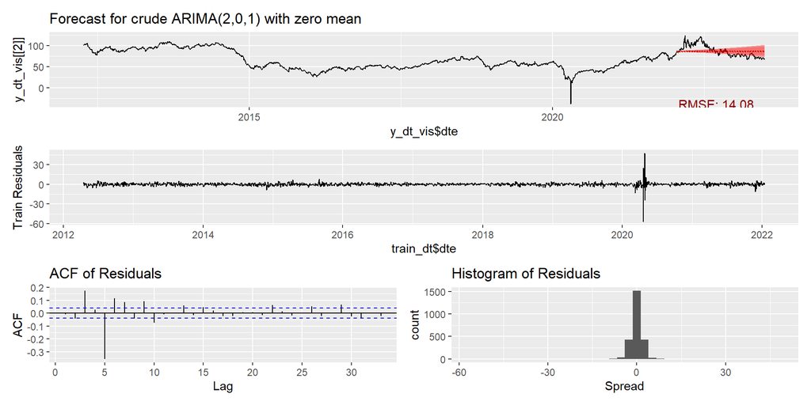

```r
fcst_bxcx_diff(y_dt = crude, y_dt_diff = crude_bxcx_diff5, y_dt_bxcx = crude_bxcx,
               lag_order = 5, diff_invert_hilo = F, lambda = lambda_crude)
```

The diff5 model however is better than the automatically created model.